R语言大作业 金小龙 补充数据 对于共享单车使用情况的分析

# Background

With the popularization of smart phones and the rapid increase of mobile phone users, shared bicycles, as an important part of the urban transportation system, are booming with the characteristics of green, environmental protection, convenience and efficiency, economy and environmental protection. By providing services on campuses, bus stations, residential areas, public service areas, etc., bicycle-sharing companies complete the last “puzzle” of the transportation industry and create synergy with other public transportation methods. Shared bicycles can help alleviate urban short-distance traffic travel and the “last mile” problem. However, due to its operational characteristics, shared bicycles pose greater challenges for companies in the planning and management of city deployment and dispatch of bicycles.

Besides, among the data given by the teacher, we have selected data about the Internet of Vehicles. Our interest lies in studying the driving behavior of people or the relationship between humans and the geographic world.

In particular, I am very interested in getting the information contained in the latitude and longitude data. However, the latitude and longitude data in the data given by the teacher is too small, and the data collection point is relatively remote, so I used the data from the https://www.heywhale.com/home website. The data is based on Shanghai Mobike's random sampling of about 100,000 open order data in August 2016 for analysis, to dig out the laws behind the data, and use the data to outline the current situation of the use of Mobike shared bicycles and user travel.In the meanwhile, We analyze the number of Mobike bicycles used to help the company rationally arrange the number of parking spots.

# Data preprocessing

```python
import pandas as pd
from math import radians, cos, sin, asin, sqrt,ceil
import numpy as np
import geohash
import matplotlib.pyplot as plt
import requests
import folium
from folium import plugins



data_bike = pd.read_csv("2016_mobike_shanghai.csv")
```

```python
# load data
data_bike.shape

data_bike.info()
```

```
<class 'pandas.core.frame.DataFrame'>
RangeIndex: 102361 entries, 0 to 102360
Data columns (total 10 columns):
 #   Column            Non-Null Count   Dtype
---  ------            --------------   -----
 0   orderid           102361 non-null  int64
 1   bikeid            102361 non-null  int64
 2   userid            102361 non-null  int64
 3   start_time        102361 non-null  object
 4   start_location_x  102361 non-null  float64
 5   start_location_y  102361 non-null  float64
 6   end_time          102361 non-null  object
 7   end_location_x    102361 non-null  float64
 8   end_location_y    102361 non-null  float64
 9   track             102361 non-null  object
dtypes: float64(4), int64(3), object(3)
memory usage: 7.8+ MB
```

```python
# convert time format
data_bike['start_time'] = pd.to_datetime(data_bike['start_time'])
data_bike['end_time'] = pd.to_datetime(data_bike['end_time'])
```

- Calculate the riding time, the unit is min.

```python
# data analyze

# Riding time the unit is min
duration = data_bike.end_time - data_bike.start_time
data_bike["duration"] = (data_bike.end_time - data_bike.start_time).dt.seconds/60
```

- Calculate the distance of the ride by the latitude and longitude of the starting point and the end of the ride, the unit is kilometers

```python
# Calculate the distance of the ride by the latitude and longitude
# of the starting point and the end of the ride, the unit is kilometers

def bike_distance(item):
    longitude_start, latitude_start, longitude_end, latitude_end = map(radians, [item["start_location_x"], item["start_location_y"], item["end_location_x"], item["end_location_y"]]) # 经纬度转换成弧度
    dist_longitude = longitude_start - longitude_end
    dist_latitude = latitude_start - latitude_end

    dist = sin(dist_latitude/2)**2 + cos(latitude_start) * cos(latitude_end) * sin(dist_longitude/2)**2

    distance = round(2 * asin(sqrt(dist)) * 6371,3)
    return distance

data_bike["dist"] = data_bike.apply(bike_distance,axis=1)
```

- Obtain the route through the trail of each bike

```python
# Obtain the route through the trail of each bike

def geo_Length(item):
    track_list = item["track"].split("#")
#     print(track_list)

    part_Length_item = {}
    global Length
    Length = 0

    for i in range(len(track_list)-1):

        start_location = track_list[i].split(",")
        end_location = track_list[i+1].split(",")

        part_Length_item["start_location_x"],part_Length_item["start_location_y"] = float(start_location[0]),float(start_location[1])
        part_Length_item["end_location_x"],part_Length_item["end_location_y"] = float(end_location[0]),float(end_location[1])

        # distance
        part_length_each = bike_distance(part_Length_item)
        Length = part_length_each + Length

    return Length


data_bike["Length"] = data_bike.apply(geo_Length,axis=1)

data_bike["Length"]
```

```
0         2.682
1         4.130
2         5.828
3         2.381
4         1.523
          ...
102356    1.062
102357    1.093
102358    0.760
102359    1.627
102360    5.583
Name: Length, Length: 102361, dtype: float64
```

- Get the day of the week corresponding to the date, like weekday and weekend

```python
# weekday and clear time

# weekday
data_bike['weekday'] = data_bike.start_time.apply(lambda x: x.isoweekday())
# clear time  the unit is h
data_bike['daytime'] = data_bike.start_time.apply(lambda x: x.utctimetuple().tm_hour)
```

- Get the number of bike use .

```python
# numbers of bike use
bike_use_times = data_bike.groupby("bikeid")["orderid"].count()
```

- Calculate the price per order ,we set 1 ￥ per 20min

```python
# cost per ride
# Calculate the price per order
# we set 1 ￥ per 20min

data_bike['cost'] = data_bike.duration.apply(lambda x: ceil(x/20))
```

# Data analyze

## Ride time distribution

Ride time distribution

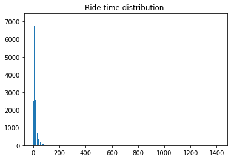

```python
# Ride time distribution
duration_summary = data_bike["duration"].value_counts().sort_index()

plt.bar(duration_summary.index,duration_summary.values);

plt.title("Ride time distribution ")
```

adjusted ride time distribution

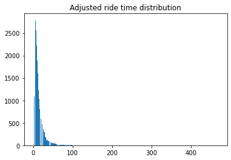

```python
# adjusted ride time distribution

data_bike['right_speed'] = data_bike['Length'] / (data_bike['duration'] / 60)

duration_right_summary = data_bike[-(((data_bike['right_speed'] < 12) | (data_bike['right_speed'] > 20)) )]["duration"].value_counts().sort_index()
plt.bar(duration_right_summary.index,duration_right_summary.values);
plt.title("Adjusted ride time distribution")
```

From the chart, we observe that the data has an obvious long tail, showing a right skewed distribution .

We know it is because the behavior of people using shared bicycles is likely to travel for short periods of time. The data range on the x-axis is very large, and this result is partly due to abnormal data records.

For the abnormal riding time data, we add a new column of "speed", and by eliminating the obviously abnormal data of the riding speed. Because the riding speed is generally 12- 20km/h, we can remove the abnormal record caused by the user forgetting to close the lock after riding.

## The number of orders distribution

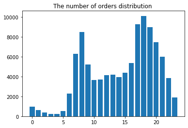

```python
# The number of orders distribution
hour_num_data = data_bike["daytime"].value_counts().sort_index()
plt.bar(hour_num_data.index,hour_num_data.values);
plt.title("The number of orders distribution ")
```

From the chart above, we get that during the period of 23-5 o'clock, people mostly rest, so the number of orders using shared bicycles is very small.

The number of orders gradually starts to increase at 6 o'clock.

During 11-14 o'clock, there is a local midday peak, because it has a certain relationship with eating out at noon or take part in some activities during the rest time.

## weekday weekend data distribution

```
<BarContainer object of 24 artists>
```

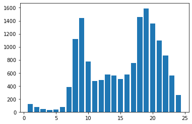

```python
# weekday weekend data distribution
weekend_order = data_bike[(data_bike["weekday"]==6) | (data_bike["weekday"]==7)]
weekday_order = data_bike[~((data_bike["weekday"]==6) | (data_bike["weekday"]==7))]

weekday_num = weekday_order["weekday"].value_counts().shape[0]
weekend_num = weekend_order["weekday"].value_counts().shape[0]

weekday_order_hour = weekday_order.groupby("daytime").count()["orderid"]/weekday_num
weekend_order_hour = weekend_order.groupby("daytime").count()["orderid"]/weekend_num

bar_width = 1
plt.bar(weekday_order_hour.index+bar_width, weekday_order_hour.values)
```

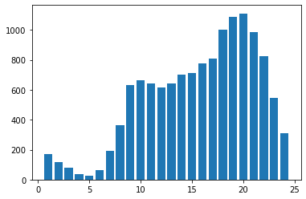

```python
plt.bar(weekend_order_hour.index+bar_width, weekend_order_hour.values);
```

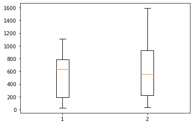

```python
plt.boxplot([weekend_order_hour.values,weekday_order_hour.values]);
```

By comparing two histograms, traffic on the weekend is dominated by non-commuting traffic. Compared with the distribution on working days, the distribution is relatively flat, and there is no obvious morning and evening rushhours.

## The ride distance distribution

```
0.095     575
0.111     480
0.146     207
0.190     219
0.206     330
         ...
24.989      1
25.012      1
25.021      1
25.023      1
25.031      1
Name: Length, Length: 32634, dtype: int64
```

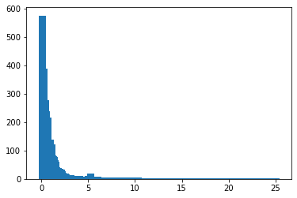

```python
Length_data = data_bike[data_bike["Length"]<=25.035]["Length"].value_counts().sort_index()
print(Length_data)
plt.bar(Length_data.index,Length_data.values);
# plt.title("The ride distance distribution ")
```

From the chart above, the riding distance distribution map roughly shows that the main riding distance is concentrated in a range of about 3 kilometers. But there are also long-distance rides, even more than 25 kilometers. Also we conclude that the larger points perhaps are the error points caused by GPS anomalies.

## Analysis of parking spots

```python
def district_diff(item):
    item["start_location_x"] = round(item["start_location_x"],2)
    item["start_location_y"] = round(item["start_location_y"],2)
    item["end_location_x"] = round(item["end_location_x"],2)
    item["end_location_y"] = round(item["end_location_y"],2)

    return item

data_bike = data_bike.apply(district_diff,axis = 1)
```

```python
data_bike["date"] = data_bike["start_time"].dt.day

max_data_ridenum = data_bike[data_bike["date"]==data_bike["date"].value_counts().index[0]]

earlist = max_data_ridenum.groupby(["bikeid"]).apply(lambda t: t[t.start_time==t.start_time.min()])
last = max_data_ridenum.groupby(["bikeid"]).apply(lambda t: t[t.start_time==t.start_time.max()])

district_out_num = earlist.groupby(["start_location_x","start_location_y"]).count()["bikeid"]
district_back_num = last.groupby(["end_location_x","end_location_y"]).count()["bikeid"]

district_out_back = pd.DataFrame({"out":district_out_num,"back":district_back_num})
district_out_back.fillna(0,inplace=True)

# the number gap of bike out and back
district_out_back["num_difference"] = district_out_back.apply(lambda t: t["back"]-t["out"],axis = 1)
```

```python
lack_bike_district = district_out_back[(district_out_back["num_difference"]) <= -5].sort_values(by=["num_difference"])

free_bike_district = district_out_back[(district_out_back["num_difference"]) >= 5].sort_values(by=["num_difference"])
```

We use the open API of the AutoNavi(Gaode) platform to obtain the specific address corresponding to the latitude and longitude

```python
# get the clear location
def API_location(location):

    location_str=str(location[0])+','+str(location[1])
    parameters = {'output': 'json', 'location': location_str, 'key': '2fbbe1979c49ea25e83e821988513d97','extensions':'all'}
    base = 'https://restapi.amap.com/v3/geocode/regeo'

    response = requests.get(base, parameters)
    answer = response.json()["regeocode"]["formatted_address"]
    return answer
```

```python
lack_location = []

for i in lack_bike_district.index:
    item_result = API_location(i)
    lack_location.append(item_result)

lack_bike_district["location"] = lack_location
```

```python
free_location = []

for i in free_bike_district.index:
    item_result = API_location(i)
    free_location.append(item_result)

free_bike_district["location"] = free_location
```

index : Latitude and longitude out : the out number from the district back : the back number to the district num_difference : the number gap of bike out and back location : clear adress

```python
print(free_bike_district.head(5))
print(lack_bike_district.head(5))
```

```
               out  back  num_difference                 location
121.43 31.35   9.0  14.0             5.0      上海市宝山区顾村镇共富饭店共富一村西区
121.49 31.26  12.0  17.0             5.0  上海市虹口区嘉兴路街道天水路金融街(海伦)中心
121.50 31.22   5.0  10.0             5.0       上海市黄浦区小东门街道悦来街悦来小区
121.51 31.19   1.0   6.0             5.0        上海市浦东新区南码头路街道临沂五村
121.46 31.22   6.0  11.0             5.0         上海市黄浦区瑞金二路街道花园饭店
               out  back  num_difference                        location
121.53 31.32  61.0  45.0           -16.0                  上海市杨浦区殷行街道国和二村
121.45 31.23  30.0  15.0           -15.0                 上海市静安区江宁路街道西康公园
121.43 31.30  13.0   1.0           -12.0                  上海市静安区彭浦镇白玉兰馨园
121.47 31.25  22.0  10.0           -12.0         上海市静安区宝山路街道虬江路1226号博园大楼
121.50 31.29  24.0  12.0           -12.0  上海市虹口区曲阳路街道松花小区(松花江路)松花小区(政肃路)
```

```python
lack_bike_district.to_csv("lack_bike_district.csv")
free_bike_district.to_csv("free_bike_district.csv")
```

```python
# create the bottom map
ShangHai_Map = folium.Map(location=[31.233705, 121.471632],zoom_start=11)

marker_cluster = plugins.MarkerCluster().add_to(ShangHai_Map)
```

```python
for i in range(0,len(lack_bike_district)-1):
#     latitude
    x=lack_bike_district.index[i][1]
#     longitude
    y=lack_bike_district.index[i][0]

    test = folium.Html("<b>The Number of missing bikes:{}</b></br><p>Location:{}</p>".format(int(lack_bike_district.iloc[i,2]),lack_bike_district.iloc[i,3]),script=True)
    popup = folium.Popup(test, max_width=1000)
    folium.Marker([x,y],popup=popup,icon=folium.Icon(color='red')).add_to(ShangHai_Map)
```

```python
for i in range(0,len(free_bike_district)-1):
    x=free_bike_district.index[i][1]
    y=free_bike_district.index[i][0]
    test = folium.Html(
        "<b>The Number of available bikes:{}</b></br><p>Location:{}</p>".format(int(free_bike_district.iloc[i,2]),free_bike_district.iloc[i,3]),
        script=True)

    popup = folium.Popup(test, max_width=1000)
    folium.Marker([x,y],popup=popup,icon=folium.Icon(color='green')).add_to(ShangHai_Map)

ShangHai_Map.save('book_provide.html')
```

```python
ShangHai_Map
```

Make this Notebook Trusted to load map: File -> Trust Notebook

[interactive chart not shown]

We can bring bicycles from the green point to the red point so that we can get a balance in the district.

Besides, from the map, we find that the red dots on the map are densely distributed near Shanghai Wujiaochang. We speculate that the reason is that there are many universities near Wujiaochang, such as Fudan University, Shanghai University of Finance and Economics, and Tongji University. The campuses of these universities are relatively small, so riding share bicycles is a cheaper and more convenient option. During the travel time on weekdays, there certainly will be a lack of bicycles at each parking spot.